# Monte Carlo Simulation

## Hedging Renewable Energy Investments with Bitcoin Mining

Authors: Bastian-Pinto, C., Araujo, F. VdS., Brandão, L. E. T., Gomes, L. L.

Abstract Renewable energy sources such as wind power are increasing their share of the world energy matrix. Nonetheless, wind farms projects are subject to variations in output due to climate conditions and to price volatility if they choose to anticipate construction to sell their energy in the short term markets. In order to create incentives for early investment, we show that wind farm investors can hedge electricity price risk by simultaneously investing in a cryptocurrency mining facility that uses electricity as input to produce newly minted Bitcoins to sell in the market. Given that electricity and Bitcoin prices are mostly uncorrelated, the ability to switch outputs between these two assets depending on their relative prices, allows the firm to maximize revenues and minimize losses. We develop a numerical application where we apply the real options approach to model a wind farm that chooses to anticipate construction in order to sell energy in the short term market for up to four years prior to entering into its long term energy sales commitment. Given that this power plant also invests in a Bitcoin mining facility, whenever the price of the Bitcoins created is higher than the market price of electric power, the firm will choose to operate the mining facility. Otherwise, it will sell its energy to the market. The short-term energy price and Bitcoin price/mining-difficulty ratio are modeled as two distinct stochastic diffusion processes. The results show that the option to switch outputs significantly increases the generator’s revenue while simultaneously decreasing the risk.

Keywords: real options, switch option, renewable energy production, cryptocurrency mining, bit-spread

This page presents the analysis of the Bitcoin Price/Difficulty construct used in the paper. All the code was run in RStudio using the version of the software below.

### Software version

```r
R.version
```

```
               _
platform       x86_64-w64-mingw32
arch           x86_64
os             mingw32
system         x86_64, mingw32
status
major          4
minor          0.1
year           2020
month          06
day            06
svn rev        78648
language       R
version.string R version 4.0.1 (2020-06-06)
nickname       See Things Now
```

### Setting of the environment

```r
# Global Chart Configurations
# Used to resize plots
require(repr)
options(repr.plot.width=8, repr.plot.height=3)
# Used to print tables inside the R Notebook
require(knitr)
```

### Loading Data

Read data from ‘Data’ folder in project structure. Data comes without headers so col.names are added. Column classes are defined since data format is previously known.

#### Price Data

```r
original.data = read.csv(file='../Data/market-price.csv', col.names=c('Date', 'Price'), colClasses=c('character', 'double'))

# Backup for verification purposes
price.data = original.data

# Adjust dates
price.data$Date = as.Date(price.data$Date, format="%m/%d/%Y")

# Show the first six lines of data
kable(head(price.data), caption="First lines of imported Price data:")
```

First lines of imported Price data:

| Date | Price |
| --- | --- |
| 2014-08-25 | 502.93 |
| 2014-08-26 | 512.56 |
| 2014-08-27 | 515.23 |
| 2014-08-28 | 510.75 |
| 2014-08-29 | 512.56 |
| 2014-08-30 | 505.96 |

#### Difficulty Data

```r
difficulty.data = read.csv(file='../Data/difficulty.csv', col.names=c('Date', 'Difficulty'), colClasses=c('Date', 'double'))

# Show the first six lines of data
kable(head(difficulty.data), caption="First lines of imported Difficulty data:")
```

First lines of imported Difficulty data:

| Date | Difficulty |
| --- | --- |
| 2009-01-06 | 0 |
| 2009-01-09 | 1 |
| 2009-01-12 | 1 |
| 2009-01-15 | 1 |
| 2009-01-18 | 1 |
| 2009-01-21 | 1 |

### Calculating the returns

```r
# Obtain log of prices
price.data$LogPrice <- log(price.data$Price)

# Calculate returns
# Use NA in the first position of the vector since diff return has one less observation
price.data$Returns <- c(NA, diff(price.data$LogPrice))
```

### Selecting a subset of the data

```r
selected.price.data <- price.data[which(price.data$Date=="2015-02-01"):nrow(price.data), ]

selected.difficulty.data <- difficulty.data[which(difficulty.data$Date=="2015-02-01"):nrow(difficulty.data), ]

selected.data <- merge(selected.price.data, selected.difficulty.data, by="Date")

# Display the number of rows (data points)
paste("There are", nrow(selected.price.data), "Price data points and", nrow(selected.difficulty.data), "Difficulty data points. The merged database have the following number of data points:", nrow(selected.data))
```

```
[1] "There are 1633 Price data points and 582 Difficulty data points. The merged database have the following number of data points: 582"
```

### Calculate Price/Difficulty Series

```r
selected.data$Price_Difficulty <- selected.data$Price * 10^8 / selected.data$Difficulty

# Display the six first and last rows of the data set
kable(head(selected.data), caption="Display the six first rows of the data set")
```

Display the six first rows of the data set

| Date | Price | LogPrice | Returns | Difficulty | Price_Difficulty |
| --- | --- | --- | --- | --- | --- |
| 2015-02-01 | 225.29 | 5.417389 | 0.0305567 | 41272873895 | 0.5458549 |
| 2015-02-04 | 226.58 | 5.423098 | -0.0036565 | 41272873895 | 0.5489804 |
| 2015-02-07 | 227.68 | 5.427941 | 0.0209488 | 41272873895 | 0.5516456 |
| 2015-02-10 | 219.67 | 5.392126 | -0.0030454 | 44455415962 | 0.4941355 |
| 2015-02-13 | 236.17 | 5.464552 | 0.0628209 | 44455415962 | 0.5312514 |
| 2015-02-16 | 235.83 | 5.463111 | 0.0109146 | 44455415962 | 0.5304865 |

```r
kable(tail(selected.data), caption="Display the six last rows of the data set")
```

Display the six last rows of the data set

|  | Date | Price | LogPrice | Returns | Difficulty | Price_Difficulty |
| --- | --- | --- | --- | --- | --- | --- |
| 577 | 2019-10-26 | 9292.025 | 9.136912 | 0.1670331 | 1.369148e+13 | 0.0678672 |
| 578 | 2019-10-29 | 9385.600 | 9.146932 | -0.0088943 | 1.369148e+13 | 0.0685507 |
| 579 | 2019-11-01 | 9147.238 | 9.121207 | -0.0035710 | 1.369148e+13 | 0.0668097 |
| 580 | 2019-11-04 | 9266.701 | 9.134183 | 0.0053030 | 1.369148e+13 | 0.0676822 |
| 581 | 2019-11-07 | 9241.038 | 9.131410 | -0.0094475 | 1.366989e+13 | 0.0676014 |
| 582 | 2019-11-10 | 8896.403 | 9.093402 | 0.0098398 | 1.272001e+13 | 0.0699402 |

### Plot Series

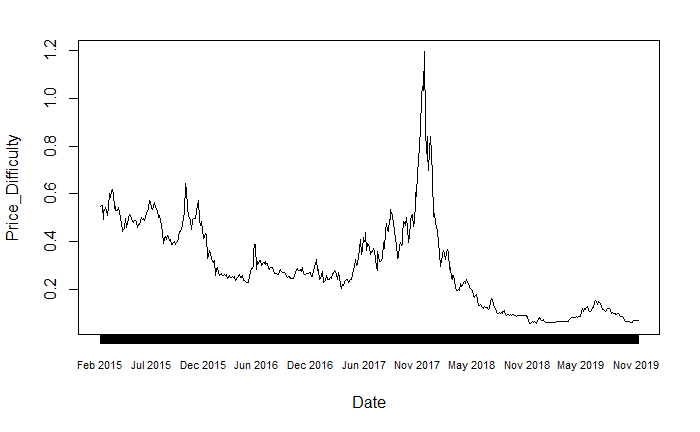

```r
plot(Price_Difficulty ~ Date, selected.data, xaxt = "n", type = "l"); axis(1, selected.data$Date, format(selected.data$Date, "%b %Y"), cex.axis = .7)
```